# Report_Chapter4

Chiara Huwiler

2023-03-20

## AGDS 4.4 Report Exercises

# Telling a story from data

This dataset contains the daily air quality measurements in New York from May to September 1973. Obtained is the data from the New York State Department of Conversation an the National Weather Service. With three relevant patterns the hypothesis: *“How is the solar radiation interfering with the ozone?”* is analysed.

```r
# Set up
library(tidyverse)
```

```r
library(ggplot2)
library(dplyr)
```

```r
# load and define the Dataset
datasets::airquality
```

[output not shown]

[output cut: 139 more lines]

```r
airquality1 <- datasets::airquality

# rename the colume Month (to be better distuinguishable, from the function month)
airquality1 <- airquality1 |>
  rename(Month_1 = Month)
knitr::kable(airquality1)
```

[output not shown]

[output cut: 123 more lines]

## Patterns

### Identifying Outliers

First the outliers were identified. That means that extreme values which could have a significant impact on the analysis or modeling of the data are identified.

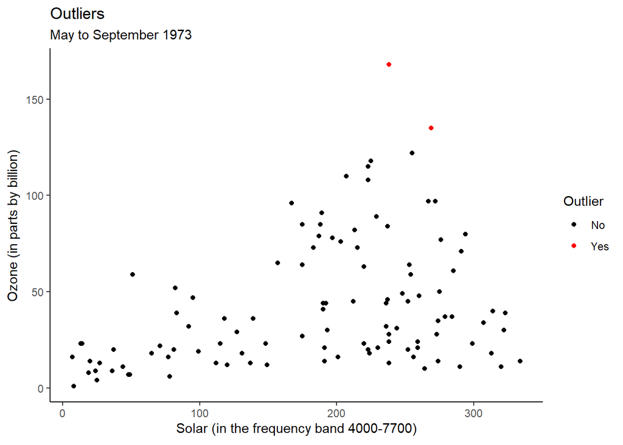

```r
# Compute the outliers
vec_outliers <- boxplot.stats(airquality1$Ozone)$out

# Create new data frame including variable outlier
plot_o <- airquality1 |>
  mutate(outlier = Ozone %in% vec_outliers)

# Create a scatterplot with marked outliers

plot_o1<- plot_o |>
  ggplot(aes(x = Solar.R, y = Ozone, color = outlier)) +
  geom_point() +
  scale_color_manual("Outlier",
                     values = c("black", "red"),
                     labels = c("No", "Yes")
                     ) +
  labs(title = "Outliers", subtitle = "May to September 1973",
    x = expression(paste("Solar (in the frequency band 4000-7700)")),
       y = expression(paste("Ozone (in parts by billion)"))) +
  theme_classic()

# View the plot
print(plot_o1)
```

```r
# Save this plot
ggsave("./figures/plot_o.jpeg", plot = plot_o1, device = "jpeg")
```

The plot shows that there is a general positive correlation between solar radiation and mean ozone level, as higher solar radiation levels tend to be associated with higher mean ozone levels. Here, two outlines are identified, about those extra caution needs to be taken to get good data.

### Correlation

Secondly a scatterplot is used. It visualize how two variables co-vary and how an added third variable (here in b, c and d) interferes with them.

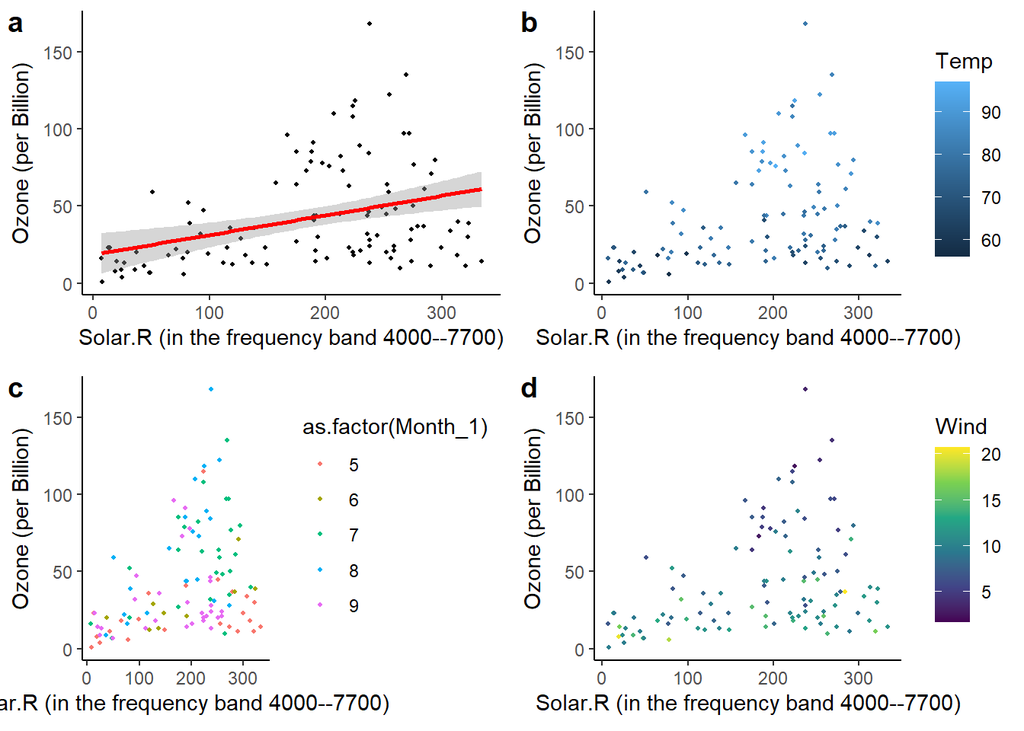

```r
# prepare plot data
airquality1_subset <- airquality1

# a: Regress Solar against Ozone
plot_a <- ggplot(
  data = airquality1_subset,
  aes(x = Solar.R, y = Ozone)) +
  geom_point(size = 0.75) +
  geom_smooth(method = "lm", color = "red") +
  labs(x = expression(paste("Solar.R (in the frequency band 4000--7700)")),
       y = expression(paste("Ozone (per Billion)"))) +
  theme_classic()

# b: Map the variable Temp on the plot
plot_b <- ggplot(
  data = airquality1_subset,
  aes(x = Solar.R, y = Ozone, color = Temp)) +
  geom_point(size = 0.75) +
  labs(x = expression(paste("Solar.R (in the frequency band 4000--7700)")),
       y = expression(paste("Ozone (per Billion)"))) +
  theme_classic()

# c: Map Months as a continous variable on the plot
plot_c <- ggplot(
  data = airquality1_subset,
  aes(x = Solar.R, y = Ozone, color = as.factor(Month_1))) +
  geom_point(size = 0.75) +
  labs(x = expression(paste("Solar.R (in the frequency band 4000--7700)")),
       y = expression(paste("Ozone (per Billion)"))) +
  theme_classic()

# d: Map Wind on the plot
plot_d <- ggplot(
  data = airquality1_subset,
  aes(x = Solar.R, y = Ozone, color = Wind)) +
  geom_point(size = 0.75) +
  labs(x = expression(paste("Solar.R (in the frequency band 4000--7700)")),
       y = expression(paste("Ozone (per Billion)"))) +
  theme_classic() +
  scale_color_viridis_c()

# combine plots
plota_d <- cowplot::plot_grid(plot_a, plot_b, plot_c, plot_d, ncol = 2, labels = "auto")
# View the plots
print(plota_d)
```

```r
# Save this plot
ggsave("./figures/plota_d.jpeg", plot = plota_d)
```

Here the results tell that a higher Temperature, as well as less wind leads to an higher ozone level.